# Fixed Effects and Clustering

# Data

Use the code below to download replication data for [Sørensen, Rune J. “The impact of state television on voter turnout.” *British Journal of Political Science* 49.1 (2019): 257-278.](https://dataverse.harvard.edu/dataset.xhtml?persistentId=doi:10.7910/DVN/QGMHHQ)

Note that, for the purposes of this analysis, you will be using only data from 1963 (the paper itself does something far more interesting, but we’ll save it for later!)

```r
library(tidyverse)

turnout_data<- dataverse::get_dataframe_by_name(
  filename = 'AggregateReplicationTVData.dta',
  .f = haven::read_dta,
  dataset = '10.7910/DVN/QGMHHQ',
  server = "dataverse.harvard.edu")

# filtering for 1963 ONLY
turnout_data<-turnout_data|>
  filter(nationalelection==0)|>
  filter(year == 1963)|>
  mutate(CountyId = factor(CountyId),
         knr = factor(knr)
         )
```

Doing some additional data cleaning to make things a little more consistent below:

```r
library(labelled)     # add variable labels to data frame

turnout_data<-turnout_data|>
  mutate(TVdummy = factor(TVdummy, levels=c(0, 1), labels=c("No", "Yes")))|>
  set_variable_labels(
  "TVdummy" = "Television Access",
  "logpop" = "Population size (log)",
  "education" = "% with higher education",
  "settlement" = "Share of population in sparseley populated areas",
  "voterpct"  = "% of population eligible to vote",
  "CountyId" = "County ID",
  "knr" = "Municipality ID"
  )
```

Each row of `turnout_data` contains information on a single municipality. The variables of interest for this analysis are as follows:

|  | Description |
| --- | --- |
| turnout | proportion turnout |
| TVdummy | Does this municipality have television access yet? (**This is the main explanatory variable of interest**) |
| logpop | Log of municipality population |
| education | % of adult population with college education |
| settlement | proportion of population that lives in sparsely populated area |
| voterpct | % of the population that is eligible to vote |
| CountyId | County ID (numeric converted to factor) |
| knr | Municipality ID (number converted to factor) |

You’ll use the following baseline model:

```r
model0<-lm(turnout ~ TVdummy + logpop + education + settlement + voterpct,
           data=turnout_data)
```

## Question 1

First we’ll estimate the three new models. I’l use `feols` from the fixest package to get both clustered standard errors and to run a fixed effects model. Note here that the default setting for `feols` is to also cluster on the fixed effect.

```r
### Q1 code
library(fixest)       # fixed effects (feols) and clustering
library(lme4)         # random effects  (lmer)
library(modelsummary) # formatted model output


# Clustering only
model1 <- feols(turnout ~
                 TVdummy + logpop + education + settlement + voterpct,
                 cluster = ~ CountyId,
                 data=turnout_data)

# fixed effects + cluster robust SEs
model2 <- feols(turnout ~
                 TVdummy + logpop + education + settlement + voterpct | CountyId,
                 data=turnout_data)

# random effects
model3 <- lmer(turnout ~
                TVdummy + logpop + education + settlement + voterpct + (1|CountyId),
                data=turnout_data)
```

Now we can make formatted output for each model:

```r
model_list<-list(
  "Clustered SE"  = model1,
  "Fixed Effect + Clustered SE" =  model2,
  "Random Effects"  = model3
  )

# for remapping model fit stats:
gofs_map <- tribble(
  ~raw, ~clean, ~fmt,
  "nobs","N",   '%.0f', # rounding to the nearest whole number
  "aic", "AIC", '%.1f', # rounding to the last digit
  "bic", "BIC", '%.1f') # rounding to the last digit



modelsummary(model_list,
             fmt = 2,
             coef_rename =TRUE,
             coef_omit ='Intercept|SD',
             gof_map = gofs_map,
             estimate  = "{estimate}",
             statistic = c("conf.int"),
             conf_level = .95,
             note = "95% CI in brackets"
             )
```

DV = % Turnout in 1963 elections

|  | Clustered SE | Fixed Effect + Clustered SE | Random Effects |
| --- | --- | --- | --- |
| Television Access [Yes] | 0.04 | 0.02 | 0.02 |
|  | [0.01, 0.06] | [-0.01, 0.04] | [0.01, 0.03] |
| Population size (log) | 0.01 | 0.01 | 0.01 |
|  | [-0.01, 0.02] | [0.00, 0.03] | [0.00, 0.02] |
| % with higher education | 0.01 | 0.01 | 0.01 |
|  | [0.00, 0.02] | [-0.01, 0.02] | [0.00, 0.02] |
| Share of population in sparseley populated areas | -0.06 | -0.03 | -0.03 |
|  | [-0.09, -0.02] | [-0.06, 0.00] | [-0.06, -0.01] |
| % of population eligible to vote | 0.01 | 0.00 | 0.00 |
|  | [0.00, 0.01] | [0.00, 0.00] | [0.00, 0.00] |
| N | 454 | 454 | 454 |
| AIC | -1211.5 | -1367.5 | -1275.7 |
| BIC | -1186.8 | -1268.7 | -1242.7 |

95% CI in brackets

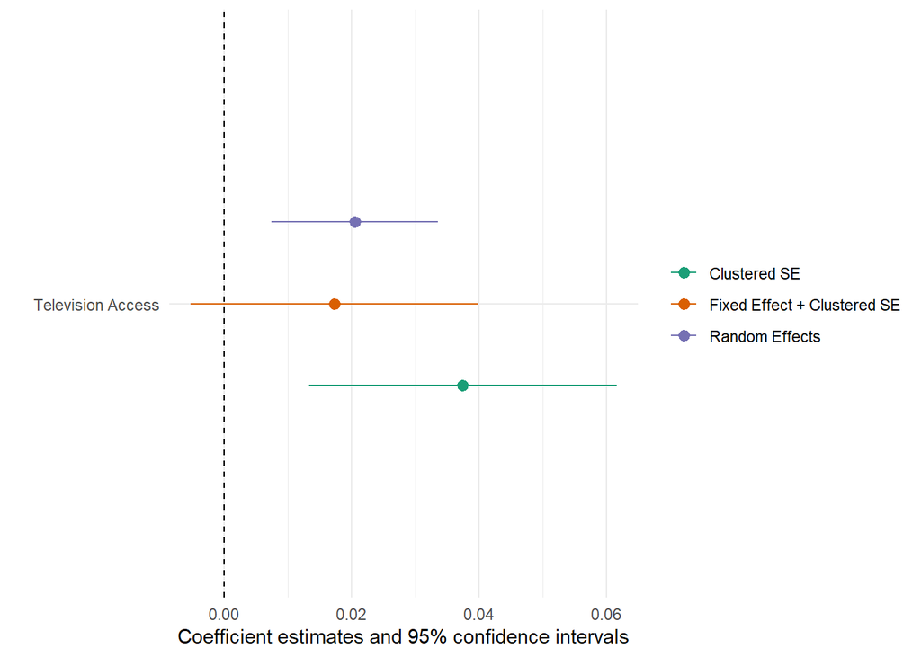

```r
modelplot(model_list, coef_map=c("TVdummyYes" = "Television Access")) +
  geom_vline(xintercept=0, lty=2) +
  scale_color_brewer(palette='Dark2')
```

We could also plot some predicted turnout levels here (although this process is a little wonky because there’s not a great way to combine them:

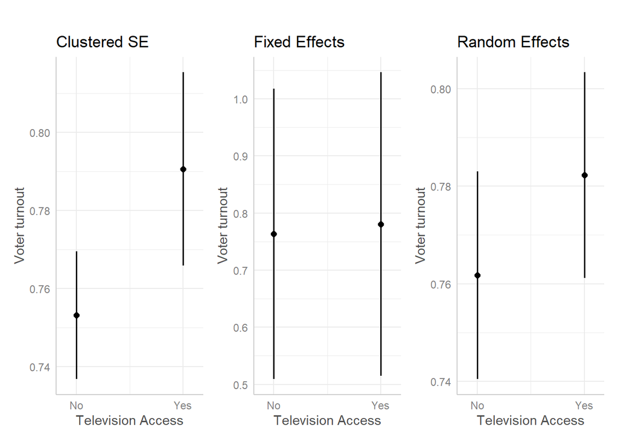

```r
library(ggeffects)
library(patchwork)
mod1preds<-predict_response(model1, terms='TVdummy',
                            margin='empirical',
                            type='response')


mod2preds<-predict_response(model2, terms='TVdummy',
                            margin='empirical',
                            type='response')


mod3preds<-predict_response(model3,
                            terms='TVdummy',
                            margin='empirical',
                            type='fixed')

plot(mod1preds) + labs(title='Clustered SE') +
plot(mod2preds) + labs(title='Fixed Effects') +
plot(mod3preds) + labs(title='Random Effects') +
  plot_annotation(title = "")
```

## Question 2

**Which of the models above seems like a better approach for this analysis? Briefly discuss some pros and cons for each one.**

A lot of different possible answers here, but I think the biggest considerations likely has to do with whether you think there are important county-level characteristics that you haven’t controlled for. The fixed effect model, because it includes a dummy for each county, is effectively controlling for any fixed characteristic of a county that might present an endogeneity problem. For instance, if counties on the west coast got TV access early because those counties had better infrastructure, and that improved infrastructure made it easier for people to get to a polling station, then a fixed effect estimator for each county would account for that difference on its own. By contrast, the only way to address this bias in a random effects model would be to actually create a measure of that characteristic and then include it in the regression model.

The primary downside is efficiency: if we don’t have any county-level endogeneity problem, then the fixed effects model is just including an additional 19 covariates and blowing up our standard errors for no good reason. This problem becomes more severe when we have lots of very small groups. While there are [some formal tests](https://www-sciencedirect-com.proxy-um.researchport.umd.edu/topics/social-sciences/hausman-test#:~:text=The%20Hausman%20test%20asks%20whether,be%20consistent%20and%20BLUE%2Defficient.) we can use to help make this decision, usually its better to have an argument for whichever one you choose.